# Exercise #3: Other probability distributions and random sampling

Patrick Applegate, patrick.applegate@psu.edu

7 September 2015

# Learning Goals

After completing this exercise, you should be able to

- generate random numbers from various probability distributions in R
- construct histograms and empirical cumulative distribution functions from sets of random numbers
- describe how changing the parameters of various probability distributions affects the shape of the distributions

# Introduction

Risk analysis often involves simulating processes that have stochastic (that is, random) components. Many of the random elements within computer models can be represented by normal distributions; however, as we saw in Part 2 of the last exercise, not all data sets are normally distributed. We need a set of methods for simulating random effects within numerical models, while accounting for the possibility that these random effects may not obey normal distributions.

But, what is a probability distribution? Loosely speaking, a probability distribution function (pdf) is a mathematical relationship that ties values of a quantity $x$ to the chance of observing particular values of that quantity. These chances (probabilities) range from 0, indicating that the associated value of $x$ is impossible, to 1, indicating that the associated value of $x$ must occur on any given trial. Assuming that *something* occurs on any given trial, integrating these probabilities over all possible values of $x$ must yield 1. Probability distributions have parameters that change the distribution’s shape, sometimes drastically.

In this exercise, you’ll perform random sampling from several probability distributions and examine two ways of plotting the results from this random sampling. You’ll also see how changing the parameters of statistical distributions change the distributions’ shape.

# Tutorial

In RStudio, open the file `lab3_sample.R` and change R’s working directory to the location of that file on your hard drive. Next, execute the script (look back at Exercise 1 if you need help with changing R’s working directory or with executing the script). A directory called `figures` should appear that contains a file called `lab3_sample_plot1.pdf`. Open this file and look at the contents. This file should contain a pair of plots that resembles Figure 1.

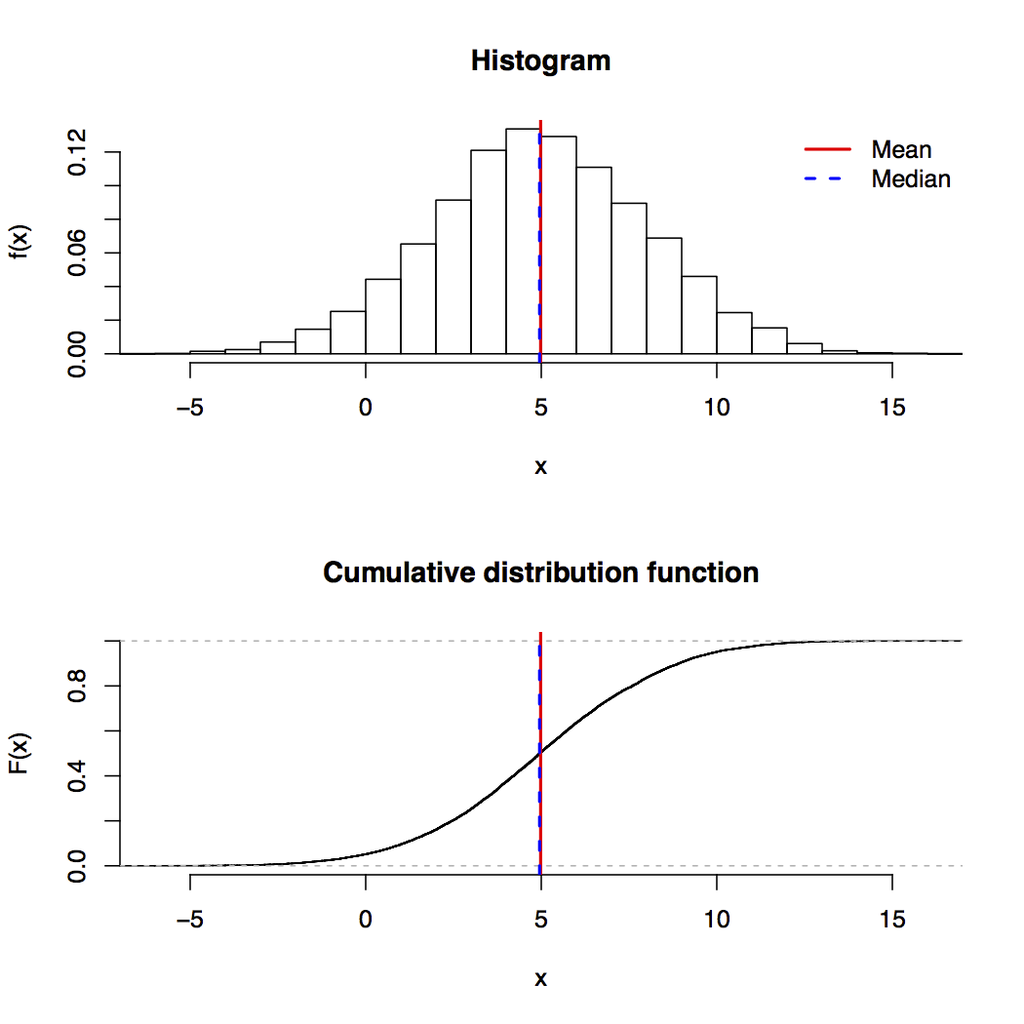

## Histograms and empirical cumulative distribution functions

In Figure 1, the top panel shows a [histogram](https://en.wikipedia.org/wiki/Histogram), and the lower panel shows an [empirical cumulative distribution function (ecdf)](https://en.wikipedia.org/wiki/Empirical_distribution_function). These plots both display the same set of randomly-generated synthetic data, in this case $n = 10^{4}$ random draws from a normal distribution with mean $\mu$ of 5 and a standard deviation $\sigma$ of 3.

In a histogram, a group of observations is sorted into bins that usually have evenly-spaced edges, and the plot is then drawn as a series of rectangles with heights that are proportional to the number of observations in each bin. In general, then, bins with taller rectangles contain more observations than those with shorter rectangles.

To construct an empirical cumulative distribution function, the data are first sorted so that the data are in order from the smallest value to the largest. The plot is drawn as a series of “stairsteps” that connect $y = 0$ on the side of the plot corresponding to small values of $x$, to $y = 1$ on the right-hand side of the plot. In between, the value of the quantity plotted on the $y$-axis increases by $1/n$ at each $x$-value corresponding to one of the observations. On Figure 1, these “stairsteps” are too small to see individually, because each one corresponds to a change in $y$ of $\Delta y = 1/n = 10^{-4}$. As a consequence of how they are constructed, empirical cumulative distribution functions always increase from small values of $x$ to larger ones; that is, they are [monotonically increasing](https://en.wikipedia.org/wiki/Monotonic_function).

The quantity plotted on the $y$-axis differs between histograms and empirical cumulative distribution functions. On a histogram, the $y$-axis represents the number of observations in each bin or (as in Figure 1) this number divided by the total number of observations. On an empirical cumulative distribution function, the $y$-axis represents the running total of the observations, going from small values of $x$ to large ones, again divided by the total number of observations.